# Session 7-2

## Session outline

1. Part 1 Recap
- How to select paths  
  - Understand HTML structure and elements
- How to use `rvest` package
2. Part 2: R Selenium
- Selenium automates browsers  
  - primarily for testing purposes but…
- To Scrap JavaScript enable pages
- Top selenium Commands

## JavaScript enable pages

### Example : class example

Try to scrape the current time

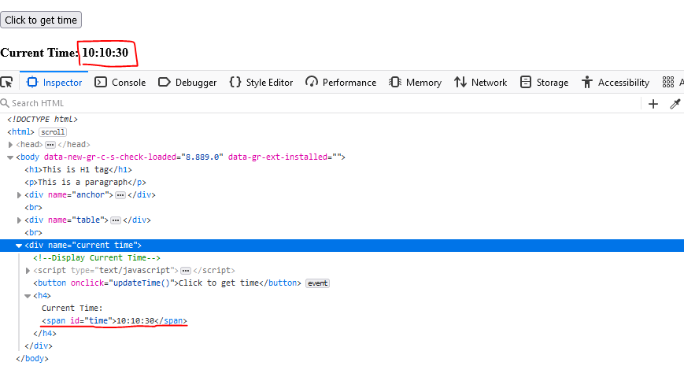

## JavaScript enable pages

### Example : [CNBC Dow 30](https://www.cnbc.com/dow-30/)

Try to scrape the Dow 30 Chart

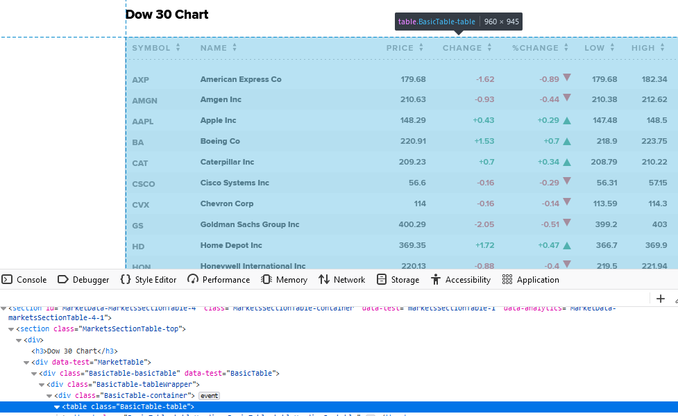

## R Selenium

### Setup

1. Installation

```r
install.packages("RSelenium")
library(RSelenium)
```

2. Check Chrome Version

Open `Chrome` >> `Menu` >> `help` >> `About Google Chrome`

[figure not shown]

## R Selenium

### Setup

3. Start a selenium server and browser: [rsDriver()](https://www.rdocumentation.org/packages/RSelenium/versions/1.7.7/topics/rsDriver) function

```r
# Check your chrome version!
driver <- rsDriver(browser = "chrome", chromever =  "95.0.4638.69")
```

If successful, a new chrome browser will launch

`Chrome is being controlled by automated test software`

[figure not shown]

## R Selenium

### Setup

4. Open and close Client

```r
driver$client$open()
driver$client$close()
rm(driver) # remove from the environment
```

5. Free port(s)

```r
# If ∃ Error "Selenium server signals port = #### is already in use"
# Free all the ports (windows)
system("taskkill /im java.exe /f", intern=FALSE, ignore.stdout=FALSE)
# Free a specific port

# Get process identifier (PID)
shell("netstat -aon | find \"<Port ####>\"")   # replace <Port ####>
# Kill PID
system("Taskkill /F /T /PID <PID>")            # replace <PID>
```

## R Selenium

### Basic Navigation

- `navigate()` function

```r
driver$client$navigate("https://www.cnbc.com/dow-30/")
```

- `goBack()` and `goForward()` functions

```r
driver$client$goBack()
driver$client$goForward()
driver$client$getCurrentUrl()  # Check the current urls
```

- `getPageSource()` function

```r
driver$client$getPageSource()[[1]] %>%
  rvest::read_html() %>%
  rvest::html_nodes(xpath='//table [@class="BasicTable-table"]') %>%
  rvest::html_table()
```

## R Selenium

### Sending Events to Elements – Click

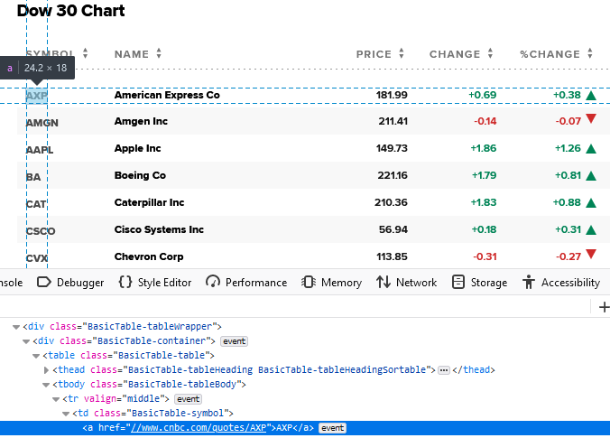

1. Use `findElement()`function and `xpath`

**NOTE**: You can search by `name`, `ID`, `class`, `CSS`.

```r
find_AXP_Elm =
  driver$client$findElement(using="xpath",'//a [contains(text(), "AXP")]')
```

2. Use `clickElement()` function to click element

```r
find_AXP_Elm$clickElement()
```

## R Selenium

### Sending Events to Elements – Sending Text and Key Press

1. `webElement$sendKeysToElement()` function

```r
driver$client$navigate("https://www.google.com")
driver$client$findElement(
  using = "xpath",'//* [@name="q"]')$sendKeysToElement(list("UF"))
# ... sendKeysToElement(list(" Marketing", key="enter")) # Press enter Key
```

2. Backspace

```r
$findElement(using = "xpath",'//* [@name="q"]')$sendKeysToElement(list("\b"))
# Or ... $sendKeysToElement(list(key="backspace"))
```

3. `ClearElement()` function

```r
$findElement(using = "xpath",'//* [@name="q"]')$clearElement()
```

Check `selKeys`

## R Selenium

### Sending Events to Elements – Scroll

1. Send Key Press

```r
driver$client$navigate("https://www.reddit.com/search/?q=emptiness")
driver$client$findElement(using = "css", "body")$sendKeysToElement(
  list(key = "end")) # "home", "page_down", "down_arrow"
```

2. Execute Javascript with `executeScript()` function

```r
# Scroll vertically down by 10000 pixel
driver$client$findElement(using = "css", "body")$executeScript(
  "scroll(0, 10000);")
# Scroll down to the end of the page
...$executeScript("window.scrollTo(0, document.body.scrollHeight)")
# Consider writing a loop for dynamic webpages
# Hint1: Check the scroll hight
...$executeScript("return document.body.scrollHeight")
# Hint2: Run a while loop with system sleep
```

## R Selenium

### Timeout

1. `Sys.sleep()`
- to pause R execution for defined time (seconds)
2. implicit
- to set a wait time before searching and locating a web element

```r
driver$client$setTimeout(type="implicit", milliseconds=1000)
```

3. page load
- to set a limit on the time that the script allots for a web page to be displayed

```r
driver$client$setTimeout(type="page load", milliseconds=1000)
```